# Week 0 Lab. Introduction to R

Craig Enders

Friday September 25

■ data frame name ■ numeric variable ■ categorical variable (factor) ■ raw data file name

# The RStudio Interface

R is the programming language that performs the computations; RStudio is the application used to interact with it. RStudio’s window is divided into four panes.

[figure not shown]

**Source editor** (top left). This is where you write and save R scripts, which are plain text files with a `.R` extension. Code in the editor does not run until you send it to the console. Place the cursor on a line (or highlight a block) and press Cmd+Return on a Mac or Ctrl+Enter on Windows. Working from a script rather than typing directly into the console leaves a record of every step that you can rerun or edit later.

**Console** (bottom left). This is where R executes commands. Every command you send from the editor appears here with its output. You can also type commands directly at the `>` prompt. Error and warning messages appear here in red.

**Environment** (top right). This lists every object currently in R’s memory: data frames, with their number of rows and columns, and single values such as a file path. Clicking a data frame opens a spreadsheet-style viewer. When you quit R, the environment is emptied, which is why the script matters.

**Files, Plots, Packages, Help** (bottom right). The Plots tab displays graphs, the Files tab browses your computer, the Packages tab lists installed packages, and the Help tab shows documentation for any function. For example, type `?read.csv` in the console to open the help page for `read.csv()`.

The next image shows the same window in the middle of a session. The editor contains a script with section headers and comments, the Environment pane lists three data frames and a file path, the console displays summary output, and the Plots tab contains a histogram.

[figure not shown]

# Installing Packages

A package is a collection of functions that extends the capabilities of base R. Packages need to be installed once and may need to be reinstalled after an update to a newer version of R. The course script [Week 0 R Package Installation Script.R](https://github.com/craigenders/psych250a/blob/main/labs/Week%200%20R%20Package%20Installation%20Script.R) contains every installation command for the class; open it in RStudio and run the whole thing. The commands are reproduced below. Installation downloads files from the internet, so it can take a few minutes, and the console will scroll a lot of text. It is finished when the `>` prompt returns.

```
install.packages('estimatr', dependencies = T)
install.packages('GGally', dependencies = T)
install.packages('ggplot2', dependencies = T)
install.packages('Hmisc', dependencies = T)
install.packages('performance', dependencies = T)
install.packages('psych', dependencies = T)
install.packages('remotes', dependencies = T)
install.packages('rstudioapi', dependencies = T)
install.packages('rstatix', dependencies = T)
install.packages('summarytools', dependencies = T)
if (!requireNamespace("tinytex", quietly = TRUE)) install.packages("tinytex")
if (Sys.which("xelatex") == "") tinytex::install_tinytex()
```

The last two lines install a small LaTeX distribution, which R Markdown needs in order to knit a document to PDF; they do nothing if it is already present. The following image shows the script open in RStudio and ready to run.

[figure not shown]

Installing a package puts it on your computer; it does not make it available in a session. That is the job of `library()`, which appears in every script and is described in the Loading Packages section below.

# R Basics

Four pieces of syntax show up in every script this course uses. They are worth learning on their own before they appear mixed together with data.

## The Assignment Operator

The assignment operator `<-` assigns the result on the right to an object on the left. Read it as “gets”: `Constant <- 1` means the object `Constant` gets the value 1. Typing an object’s name by itself prints its contents. Assignment creates everything from a single number to an entire dataset, and the resulting objects appear in the Environment pane. RStudio inserts the operator with Option+Minus on a Mac or Alt+Minus on Windows.

```r
# define a new object called Constant that equals 1
Constant <- 1

# print the contents of Constant
Constant
```

```
[1] 1
```

## Vectors

A vector holds a set of values of the same type, such as numeric or character values. The `c()` function creates a vector, and the `c` stands for combine. Vectors often appear as function arguments: a set of variable names to analyze, a pair of numbers defining the limits of an axis, or a list of codes and their labels. Text values go in quotes; numbers do not.

```r
# define a new object called vars2analyze with the names of three variables
vars2analyze <- c("Depression", "Optimism", "VisImpair")

# define a new object called axis_limits with two numeric values
axis_limits <- c(0, 10)

# print the contents of both objects
vars2analyze
```

```
[1] "Depression" "Optimism"   "VisImpair"
```

```r
axis_limits
```

```
[1]  0 10
```

## Comments

The `#` is a special comment symbol that tells R to ignore any text that follows on the same line. Comments are notes to yourself and anyone reading the script. They explain what a line does and why. Every code block in this document has a comment above each command, and the assignment templates use comments to mark where your code goes. A comment can also switch a line off without deleting it: put a `#` in front of a command and R skips it.

```r
# this is a comment statement that will be ignored

# define a new object called Constant that equals 1
Constant <- 1

# the next line is switched off, so Constant stays equal to 1
# Constant <- 2
```

## Section Headers

A comment of the form `# TEXT ----` (a `#`, some text, and at least four dashes) is called a section header or code section marker. Section headers organize an R script, and RStudio displays them in a navigation menu at the bottom of the editor. The course scripts use one header per analysis step.

```r
# DEFINE A CONSTANT ----

# define a new object called Constant that equals 1
Constant <- 1

# DEFINE A VECTOR ----

# define a new object called axis_limits with two numeric values
axis_limits <- c(0, 10)
```

Clicking the section menu at the bottom of the editor lists every header in the lab script, and choosing one jumps to that section:

[figure not shown]

# The Data

The data for this lab come from a study of uveal melanoma, a rare eye cancer that can threaten vision and life. This prospective longitudinal study examined whether visual impairment predicted depressive symptoms in 299 adults undergoing diagnostic evaluation and whether optimism and pessimism moderated that relationship (MacDonald, Jorge-Miller, Enders, McCannel, Beran, & Stanton, 2021, *Health Psychology*, 40, 408–417).

Based on a clinical evaluation for a possible intraocular malignancy, participants were classified as having malignant or nonmalignant diagnoses. Three numeric variables are of primary interest.

**Depressive symptoms.** The Center for Epidemiologic Studies Depression Scale (CES-D) is a 20-item inventory that asks people to rate how often they experience depressive symptoms such as restless sleep, poor appetite, and feeling lonely. Each item is scored 0 (rarely or none of the time) to 3 (most or all of the time), so the summed score ranges from 0 to 60. Higher scores indicate greater depressive symptoms, and scores of 16 or higher indicate clinically elevated symptoms.

**Dispositional optimism.** The Life Orientation Test–Revised (LOT-R) optimism subscale consists of three items that ask people to rate their tendency to expect positive outcomes in life, each on a five-point scale from 0 (I disagree a lot) to 4 (I agree a lot). The summed score ranges from 0 to 12.

**Visual impairment.** The Measure of Outcome in Ocular Disease vision subscale (MOOD-V) is a 13-item measure. Scores were summed and transformed to a 0–100 scale, with higher scores indicating greater impairment.

| Variable | Description | Scale |
| --- | --- | --- |
| `Participant` | Participant identifier | 1 to 299 |
| `Diagnosis` | Result of the diagnostic biopsy | 0 = Non-malignant, 1 = Malignant |
| `Age` | Age in years | 19 to 91 |
| `Male` | Respondent sex | 0 = Female, 1 = Male |
| `Comorbids` | Number of medical comorbidities | 0 = none, 1 = one, 2 = two or more |
| `Optimism` | LOT-R optimism subscale (sum of 3 items) | 0 to 12 |
| `Depression` | CES-D depressive symptoms (sum of 20 items) | 0 to 60 |
| `VisImpair` | MOOD-V visual impairment (transformed) | 0 to 100 |

Notice that the categorical variables are entered as numbers, not labels: `Diagnosis` and `Male` are coded 0 and 1, and `Comorbids` is coded 0, 1, and 2. In the raw file there is nothing to tell R that these codes are categories rather than quantities, which is why the labels in the table above matter. A later step uses the `factor()` function to attach those labels to the data.

# Preliminaries: Loading Packages

R’s built-in functions handle basic statistics, but some tools in this lab come from add-on packages. `library()` makes a package’s functions available for the current session. Run it each time you open R after installing the package (see the Week 0 R Package Installation Script).

```r
# summarytools provides dfSummary() for data summaries
library(summarytools)

# rstudioapi talks to RStudio, used here to find the folder that contains this script
library(rstudioapi)
```

# Importing Data

The data files for this course are `.csv` (comma-separated values) files. A `.csv` file is a plain text format with variables separated by commas, usually with the variable names in the first row and one row of data per person. Any spreadsheet program can open or create one, and because it is plain text, R can read it without any special software. Opened in a text editor, `Cancer.csv` looks like this: the variable names on the first line, then one line per participant with the values separated by commas.

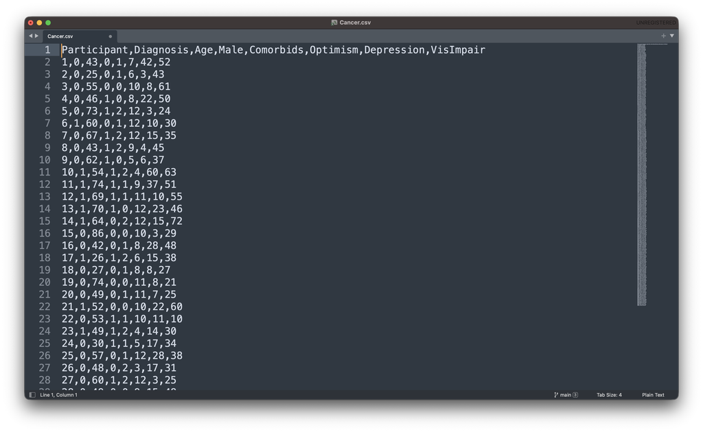

Opened in Excel, the same file is parsed into columns, one per variable, with one row per participant. Excel is convenient for looking at a `.csv` file, but save any edits back in `.csv` format, not as an Excel workbook.

[figure not shown]

Reading a `.csv` file into R parses the comma-separated values into columns and stores the result in a *data frame*. A data frame is R’s container for a rectangular dataset: rows are cases (here, participants) and columns are variables, each with a name taken from the first row of the file. Nearly everything in the course, from summaries to graphs to statistical tests, operates on a data frame or on columns pulled out of one.

There are two ways to get the data file into R. This document uses the first. The second is included for working with files stored on your own computer.

Both methods call `read.csv()` with `stringsAsFactors = TRUE`, the same call used in the assignments. The argument converts any text column to a factor, but this file has none: the categorical variables `Diagnosis` and `Male` are stored as 0/1 codes and `Comorbids` as 0/1/2 codes, so every column, including these, is read as numeric. R will happily compute a mean of `Diagnosis` unless told otherwise. A later section converts those codes to factors by hand.

## Option 1: Read From the Course Website

The data file lives on the course GitHub site. Store the web address in an object, then hand that address to `read.csv()`. Keeping the address in its own object is a small convenience: if the file moves, only one line changes.

```r
# store the web address of the raw data file
filepath <- "https://raw.githubusercontent.com/craigenders/psych250a/main/data/Cancer.csv"

# read the file at that address into a data frame named Cancer
Cancer <- read.csv(filepath, stringsAsFactors = TRUE)
```

## Option 2: Read From the Folder That Contains the Script

When a data file is saved in the same folder as your R script, you can point R at that folder and then refer to the file by name alone. The rstudioapi package asks RStudio for the path of the script you are currently editing; `dirname()` strips the file name to leave the folder, and `setwd()` makes that folder R’s working directory. `getwd()` prints the working directory so you can confirm it landed where you expected. After that, `read.csv()` needs only the file name.

This block is displayed but not run, because a knitted document has no script to locate. Run it from an R script saved next to `Cancer.csv`. In the lab script the same lines are commented out; remove the leading `#` to use them.

```r
# set the working directory to the folder that contains this script
setwd(dirname(getActiveDocumentContext()$path))

# print the working directory to confirm the location
getwd()

# read Cancer.csv from the working directory into a data frame named Cancer
Cancer <- read.csv("Cancer.csv", stringsAsFactors = TRUE)
```

# Viewing the Data

A data frame is R’s name for a rectangular dataset: one row per participant and one column per variable. `head()` prints the first six rows and `tail()` the last six. Looking at both ends provides a quick check that the file was read correctly: the column names are right, the values look plausible, and the number of rows matches what you expected. RStudio also has a spreadsheet-style viewer: type `View(Cancer)` in the console, or click the data frame’s name in the Environment pane, to open the full data frame in a tab of the editor. The Summary button in the viewer adds a small graph of each variable’s distribution.

[figure not shown]

```r
# print the first six rows of the data frame
head(Cancer)
```

```
  Participant Diagnosis Age Male Comorbids Optimism Depression VisImpair
1           1         0  43    0         1        7         42        52
2           2         0  25    0         1        6          3        43
3           3         0  55    0         0       10          8        61
4           4         0  46    1         0        8         22        50
5           5         0  73    1         2       12          3        24
6           6         1  60    0         1       12         10        30
```

```r
# print the last six rows of the data frame
tail(Cancer)
```

```
    Participant Diagnosis Age Male Comorbids Optimism Depression VisImpair
294         294         0  44    1         1        9          9        30
295         295         0  65    0         1       10         10        25
296         296         0  58    0         2        9         14        48
297         297         0  67    1         1        7          6        24
298         298         1  67    1         0       11          7        25
299         299         1  76    0         2        9          8        33
```

# Converting Categorical Variables to Factors

R does not know that `Diagnosis` and `Male` are categorical; it sees two numeric columns of 0s and 1s. Left that way, plotting and summary functions would treat them as continuous variables. The `factor()` function converts a numeric column to a *factor*, R’s term for a categorical variable. The `levels` argument lists the codes in the data, and the `labels` argument gives each code a name; the two are matched in order, so 0 becomes the first label and 1 the second.

The conversion replaces each column in place. Once a column is a factor, re-running `factor()` on it with the same `levels` would produce all `NA` values, because the codes no longer exist, so run this block only once after reading the data.

```r
# convert Diagnosis from 0/1 codes to a factor with descriptive labels
Cancer$Diagnosis <- factor(Cancer$Diagnosis,
                           levels = c(0, 1),
                           labels = c("Non-malignant", "Malignant"))

# convert Male from 0/1 codes to a factor with descriptive labels
Cancer$Male <- factor(Cancer$Male,
                      levels = c(0, 1),
                      labels = c("Female", "Male"))

# print the first few rows to confirm the labels replaced the codes
head(Cancer)
```

```
  Participant     Diagnosis Age   Male Comorbids Optimism Depression VisImpair
1           1 Non-malignant  43 Female         1        7         42        52
2           2 Non-malignant  25 Female         1        6          3        43
3           3 Non-malignant  55 Female         0       10          8        61
4           4 Non-malignant  46   Male         0        8         22        50
5           5 Non-malignant  73   Male         2       12          3        24
6           6     Malignant  60 Female         1       12         10        30
```

# Summarizing Data

`dfSummary()` from the summarytools package produces one row per variable showing its type, a compact summary of its values, a small graph of its distribution, and the number of valid and missing cases. It provides a quick way to confirm that a file was read correctly and to detect a variable stored as the wrong type, an impossible value, or unexpected missingness before it affects later analyses.

Putting the data frame name inside the parentheses, `dfSummary(Cancer)`, summarizes the entire dataset. In the HTML version of this lab, the table is handed to `print()` with `method = "render"` so that it displays as formatted HTML; that wrapper is not needed in your own documents.

```r
# overview of every variable in the data frame
print(dfSummary(Cancer), method = "render")
```

Data Frame Summary

Cancer

**Dimensions**: 299 x 8  
**Duplicates**: 0

| **No** | **Variable** | **Stats / Values** | **Freqs (% of Valid)** | **Graph** | **Valid** | **Missing** |
| --- | --- | --- | --- | --- | --- | --- |
| 1 | Participant [integer] | Mean (sd) : 150 (86.5) min ≤ med ≤ max: 1 ≤ 150 ≤ 299 IQR (CV) : 149 (0.6) | 299 distinct values (Integer sequence) |  | 299 (100.0%) | 0 (0.0%) |
| 2 | Diagnosis [factor] | 1. Non-malignant 2. Malignant | 192 ( 64.2% ) 107 ( 35.8% ) |  | 299 (100.0%) | 0 (0.0%) |
| 3 | Age [integer] | Mean (sd) : 59 (13.9) min ≤ med ≤ max: 19 ≤ 60 ≤ 91 IQR (CV) : 17.5 (0.2) | 61 distinct values |  | 299 (100.0%) | 0 (0.0%) |
| 4 | Male [factor] | 1. Female 2. Male | 138 ( 46.2% ) 161 ( 53.8% ) |  | 299 (100.0%) | 0 (0.0%) |
| 5 | Comorbids [integer] | Mean (sd) : 0.9 (0.7) min ≤ med ≤ max: 0 ≤ 1 ≤ 2 IQR (CV) : 1 (0.8) | 0 : 91 ( 30.4% ) 1 : 135 ( 45.2% ) 2 : 73 ( 24.4% ) |  | 299 (100.0%) | 0 (0.0%) |
| 6 | Optimism [integer] | Mean (sd) : 8.6 (2.9) min ≤ med ≤ max: 0 ≤ 9 ≤ 12 IQR (CV) : 4 (0.3) | 13 distinct values |  | 299 (100.0%) | 0 (0.0%) |
| 7 | Depression [integer] | Mean (sd) : 14.9 (11.4) min ≤ med ≤ max: 0 ≤ 11 ≤ 60 IQR (CV) : 13 (0.8) | 50 distinct values |  | 299 (100.0%) | 0 (0.0%) |
| 8 | VisImpair [integer] | Mean (sd) : 42 (15.1) min ≤ med ≤ max: 10 ≤ 40 ≤ 90 IQR (CV) : 20.5 (0.4) | 66 distinct values |  | 299 (100.0%) | 0 (0.0%) |

Generated by summarytools 1.1.5 ([R](https://www.r-project.org/) version 4.6.1)  
2026-10-16

The `$` operator extracts one column from a data frame: `Cancer$Depression` is the `Depression` variable by itself. Handing a single column to `dfSummary()` summarizes just that variable.

```r
# overview of the single variable Depression
print(dfSummary(Cancer$Depression), method = "render")
```

Data Frame Summary

Cancer

**Dimensions**: 299 x 1  
**Duplicates**: 249

**No**

**Variable**

**Stats / Values**

**Freqs (% of Valid)**

**Graph**

**Valid**

**Missing**

1

Depression [integer]

| Mean (sd) : 14.9 (11.4) |
| --- |
| min ≤ med ≤ max: |
| 0 ≤ 11 ≤ 60 |
| IQR (CV) : 13 (0.8) |

50 distinct values

299 (100.0%)

0 (0.0%)

Generated by summarytools 1.1.5 ([R](https://www.r-project.org/) version 4.6.1)  
2026-10-16

# Computing a New Variable

Assigning to a column name that does not yet exist adds that column to the data frame. Here the new variable `logDepression` is the natural logarithm of `Depression`. The `+ 1` inside `log()` is necessary because the CES-D has a minimum of 0 and the logarithm of 0 is undefined. Adding 1 makes the transformation defined for every score. The original `Depression` column is unchanged.

The summary below shows the original and new variables side by side. This illustrates another way to select variables: `Cancer[, c("Depression", "logDepression")]` uses a vector of names inside the square brackets to keep just those two columns, and `dfSummary()` summarizes the result. Compare it with `Cancer$Depression`, which extracts a single column, and `Cancer`, which summarizes everything.

```r
# create logDepression as the natural log of Depression plus 1
Cancer$logDepression <- log(Cancer$Depression + 1)

# overview of the original and the new variable
print(dfSummary(Cancer[, c("Depression", "logDepression")]), method = "render")
```

Data Frame Summary

Cancer

**Dimensions**: 299 x 2  
**Duplicates**: 249

| **No** | **Variable** | **Stats / Values** | **Freqs (% of Valid)** | **Graph** | **Valid** | **Missing** |
| --- | --- | --- | --- | --- | --- | --- |
| 1 | Depression [integer] | Mean (sd) : 14.9 (11.4) min ≤ med ≤ max: 0 ≤ 11 ≤ 60 IQR (CV) : 13 (0.8) | 50 distinct values |  | 299 (100.0%) | 0 (0.0%) |
| 2 | logDepression [numeric] | Mean (sd) : 2.5 (0.7) min ≤ med ≤ max: 0 ≤ 2.5 ≤ 4.1 IQR (CV) : 1 (0.3) | 50 distinct values |  | 299 (100.0%) | 0 (0.0%) |

Generated by summarytools 1.1.5 ([R](https://www.r-project.org/) version 4.6.1)  
2026-10-16

The `Cancer$` on the left side of the assignment is what makes the result a column of the data frame. Leave it off, and R still computes the same 299 values, but it stores them in a free-standing vector that has nothing to do with the `Cancer` data frame. The code below creates a vector as a separate object in memory: it shows up under Values rather than Data in the Environment pane, `dfSummary(Cancer)` does not know it exists, and it does not travel with the data frame. Free-standing objects have their uses (the constants and vectors in the R Basics section are examples), but when the goal is a new variable in the dataset, assign to the data frame using a two-part name that combines the data frame name and the new variable name (e.g., `Cancer$logDepression`).

```r
# the same computation without Cancer$ creates a vector outside the data frame
logDepVector <- log(Cancer$Depression + 1)

# print the first six values of the vector
head(logDepVector)
```

```
[1] 3.761200 1.386294 2.197225 3.135494 1.386294 2.397895
```

```r
# the data frame still has the same columns as before
names(Cancer)
```

```
[1] "Participant"   "Diagnosis"     "Age"           "Male"          "Comorbids"     "Optimism"
[7] "Depression"    "VisImpair"     "logDepression"
```

# Recoding a Variable

`ifelse()` evaluates a condition for every row and returns one value where the condition is true and another where it is false. The condition `Cancer$Depression >= 16` is the CES-D cutoff for clinically elevated symptoms, so the new variable `ClinicalSymp` equals 1 for participants at or above the cutoff and 0 for everyone else.

Like `Diagnosis` and `Male` in the raw file, the new variable is stored as 0s and 1s, so R treats it as a number. The same `factor()` call used earlier converts it to a categorical variable with descriptive labels, and the summary then reports counts and percentages for each category, which is the summary that makes sense for a categorical variable.

```r
# create ClinicalSymp: 1 if Depression is 16 or higher, otherwise 0
Cancer$ClinicalSymp <- ifelse(Cancer$Depression >= 16, 1, 0)

# convert ClinicalSymp from 0/1 codes to a factor with descriptive labels
Cancer$ClinicalSymp <- factor(Cancer$ClinicalSymp,
                              levels = c(0, 1),
                              labels = c("Subclinical Range", "Clinical Range"))

# overview of the new variable
print(dfSummary(Cancer$ClinicalSymp), method = "render")
```

Data Frame Summary

Cancer

**Dimensions**: 299 x 1  
**Duplicates**: 297

**No**

**Variable**

**Stats / Values**

**Freqs (% of Valid)**

**Graph**

**Valid**

**Missing**

1

ClinicalSymp [factor]

| 1. Subclinical Range |
| --- |
| 2. Clinical Range |

| 198 | ( | 66.2% | ) |
| --- | --- | --- | --- |
| 101 | ( | 33.8% | ) |

299 (100.0%)

0 (0.0%)

Generated by summarytools 1.1.5 ([R](https://www.r-project.org/) version 4.6.1)  
2026-10-16

# Saving and Loading an R Data File

Everything done so far lives only in R’s memory and disappears when the session ends. `save()` writes a data frame to an `.RData` file, and `load()` reads it back into a later session with the new variables and factor conversions intact. The file path names the location; `~` is shorthand for your home folder, so `~/Desktop/Cancer.RData` is a file named `Cancer.RData` on the desktop.

This block is displayed but not run, so that knitting the document does not write a file to your desktop.

```r
# save the Cancer data frame to an R data file on the desktop
save(Cancer, file = "~/Desktop/Cancer.RData")

# load the Cancer data frame from the R data file on the desktop
load("~/Desktop/Cancer.RData")
```

# Subsetting Data

Square brackets select part of a data frame. The general form is `Cancer[rows, columns]`: whatever appears before the comma picks rows, and whatever appears after it picks columns. Leaving a position empty keeps everything in that dimension.

## Selecting Variables

A vector of column names after the comma keeps only those variables. The result is a new, narrower data frame; `dim()` prints the number of rows and columns, confirming that the row count is unchanged and the column count dropped to three.

```r
# create CancerSubset containing only Optimism, Depression, and VisImpair
CancerSubset <- Cancer[, c("Optimism", "Depression", "VisImpair")]

# print the number of rows and columns of the original data frame
dim(Cancer)
```

```
[1] 299  10
```

```r
# print the number of rows and columns of the subset
dim(CancerSubset)
```

```
[1] 299   3
```

## Selecting Cases

A logical condition before the comma keeps only the rows where the condition is true. `Cancer$Diagnosis == "Malignant"` is true for participants with a malignant diagnosis, so `CancerMalig` contains just those rows and every column. Here `dim()` confirms the column count is unchanged and the row count dropped.

```r
# create CancerMalig containing only participants with a malignant diagnosis
CancerMalig <- Cancer[Cancer$Diagnosis == "Malignant", ]

# print the number of rows and columns of the original data frame
dim(Cancer)
```

```
[1] 299  10
```

```r
# print the number of rows and columns of the subset
dim(CancerMalig)
```

```
[1] 107  10
```

# R Markdown Documents

An R script provides a record of what you ran, but it contains only code. R Markdown adds the rest of the story by combining headings, written explanation, and R code in a finished report (such as this page). When you *knit* the file, R runs each code chunk in order and places its output (tables, numbers, and graphs) directly below the code that produced it. Nothing is pasted by hand, so the report is a reproducible record of the workflow: change the data or the code, knit again, and every result updates. The course assignments and Data Blitz reports are written this way.

## The Template

Every document in this course starts from the same skeleton. Download the template ([Week 0 R Markdown Template.Rmd](https://github.com/craigenders/psych250a/blob/main/labs/Week%200%20R%20Markdown%20Template.Rmd)) and open it in RStudio. It looks like this:

````r
---
title: "This is the Document Title"
author: "YOUR NAME"
date: "`r format(Sys.Date(), '%B %d, %Y')`"
output:
  pdf_document:
    toc: true
    toc_depth: 2
    latex_engine: xelatex
  html_document:
    toc: true
    toc_float:
      collapsed: false
      smooth_scroll: false
    toc_depth: 2
    theme: cosmo
    highlight: haddock
header-includes:
  - \usepackage{fvextra}
  - \DefineVerbatimEnvironment{Highlighting}{Verbatim}{breaklines,breakanywhere,commandchars=\\\{\}}
  - \fvset{breaklines=true, breakanywhere=true}
  - \RecustomVerbatimEnvironment{verbatim}{Verbatim}{breaklines,breakanywhere}
editor_options:
  chunk_output_type: console
---

```{r include=FALSE}
knitr::opts_chunk$set(
  echo = TRUE,
  message = FALSE,
  warning = FALSE,
  error = TRUE,
  comment = "",
  fig.width = 8,
  fig.height = 5)

options(scipen = 999, width = 80)
```

# This is a Title

Add text here.

```{r}
# Add code here
```

## This is a Subtitle

Add text here.

```{r}
# Add code here
```
````

The block between the two `---` lines at the top is the YAML header. It sets the document title, the author, the date, and the two output formats the document can be knitted to (a PDF, or an HTML page with a floating table of contents), along with some formatting settings. You do not need to edit any of it except the `author:` line, where you replace YOUR NAME with your name. Leave every other line unchanged. The gray chunk after the header sets display options for the entire document and should also remain unchanged.

Below the header there are only three kinds of content, and the template contains one example of each.

**Headings.** A line beginning with `#` and a space is a top-level heading, and a line beginning with `##` is a subheading underneath it. Headings organize the document and become the entries in the table of contents. Use Title Case, as in the template.

**Text.** Anything that is not a heading or a code chunk is ordinary text. Type explanations in plain sentences, exactly as you would in a word processor; a blank line starts a new paragraph.

**Code chunks.** A code chunk starts with a line containing `` ```{r} `` and ends with a line containing `` ``` ``. Everything between those lines is R code. When the document is knitted, R runs the code and displays the output underneath. RStudio inserts an empty chunk with Cmd+Option+I on a Mac or Ctrl+Alt+I on Windows. Otherwise, the code works as it does in a script, including comments, section headers, and assignment.

## From Script to Document

Here is a short R script built from pieces of this lab. It loads a package, imports the data, converts two variables to factors, and summarizes the data frame.

```
# summarytools provides dfSummary() for data summaries
library(summarytools)

# IMPORTING DATA ----

# store the web address of the raw data file
filepath <- "https://raw.githubusercontent.com/craigenders/psych250a/main/data/Cancer.csv"

# read the file at that address into a data frame named Cancer
Cancer <- read.csv(filepath, stringsAsFactors = TRUE)

# CONVERTING CATEGORICAL VARIABLES TO FACTORS ----

# convert Diagnosis from 0/1 codes to a factor with descriptive labels
Cancer$Diagnosis <- factor(Cancer$Diagnosis,
                           levels = c(0, 1),
                           labels = c("Non-malignant", "Malignant"))

# convert Male from 0/1 codes to a factor with descriptive labels
Cancer$Male <- factor(Cancer$Male,
                      levels = c(0, 1),
                      labels = c("Female", "Male"))

# print the first few rows to confirm the labels replaced the codes
head(Cancer)

# SUMMARIZING DATA ----

# overview of every variable in the data frame
dfSummary(Cancer)
```

Turning the script into a document is mostly a matter of moving pieces into the template. Each section header in the script (`# IMPORTING DATA ----`) becomes a heading in the document (`# Importing Data`). The code under each header goes into a separate code chunk. A sentence or two above each chunk explains what the code does and why. The code itself does not change at all. The finished document ([Week 0 R Markdown Example.Rmd](https://github.com/craigenders/psych250a/blob/main/labs/Week%200%20R%20Markdown%20Example.Rmd)) looks like this:

````r
---
title: "Week 0 Example: Cancer Data"
author: "YOUR NAME"
date: "`r format(Sys.Date(), '%B %d, %Y')`"
output:
  pdf_document:
    toc: true
    toc_depth: 2
    latex_engine: xelatex
  html_document:
    toc: true
    toc_float:
      collapsed: false
      smooth_scroll: false
    toc_depth: 2
    theme: cosmo
    highlight: haddock
header-includes:
  - \usepackage{fvextra}
  - \DefineVerbatimEnvironment{Highlighting}{Verbatim}{breaklines,breakanywhere,commandchars=\\\{\}}
  - \fvset{breaklines=true, breakanywhere=true}
  - \RecustomVerbatimEnvironment{verbatim}{Verbatim}{breaklines,breakanywhere}
editor_options:
  chunk_output_type: console
---

```{r include=FALSE}
knitr::opts_chunk$set(
  echo = TRUE,
  message = FALSE,
  warning = FALSE,
  error = TRUE,
  comment = "",
  fig.width = 8,
  fig.height = 5)

options(scipen = 999, width = 80)
```

# Loading Packages

The summarytools package provides dfSummary() for data summaries.

```{r}
# summarytools provides dfSummary() for data summaries
library(summarytools)
```

# Importing Data

The data file lives on the course GitHub site. Store the web address in an
object, then hand that address to read.csv().

```{r}
# store the web address of the raw data file
filepath <- "https://raw.githubusercontent.com/craigenders/psych250a/main/data/Cancer.csv"

# read the file at that address into a data frame named Cancer
Cancer <- read.csv(filepath, stringsAsFactors = TRUE)
```

# Converting Categorical Variables to Factors

Diagnosis and Male are stored as 0/1 codes. factor() converts each one
to a categorical variable with descriptive labels.

```{r}
# convert Diagnosis from 0/1 codes to a factor with descriptive labels
Cancer$Diagnosis <- factor(Cancer$Diagnosis,
                           levels = c(0, 1),
                           labels = c("Non-malignant", "Malignant"))

# convert Male from 0/1 codes to a factor with descriptive labels
Cancer$Male <- factor(Cancer$Male,
                      levels = c(0, 1),
                      labels = c("Female", "Male"))

# print the first few rows to confirm the labels replaced the codes
head(Cancer)
```

# Summarizing Data

dfSummary() gives an overview of every variable in the data frame.

```{r}
# overview of every variable in the data frame
dfSummary(Cancer)
```
````

## Knitting

To produce the report, use the **Knit** button at the top of the editor. Clicking the button itself knits to the first format listed in the YAML header, which is PDF in this template.

[figure not shown]

Clicking the small arrow next to the button opens a menu with the individual choices. Knit to PDF and Knit to HTML are the two you will use: assignments must be submitted as PDFs, and the HTML version is handy while you are working because its table of contents is clickable.

[figure not shown]

Here is the top of the example document knitted to HTML. The `title:` and `author:` lines from the YAML header appear at the top of the page. Each `#` heading became a section heading, and the same headings appear in the navigable outline on the left, where clicking an entry jumps to that section. The text you typed appears as ordinary paragraphs, and each code chunk appears as a gray box with its output directly beneath it. Notice that the `#` lines inside the chunks are still comments, shown in green as part of the code; only a `#` outside a chunk makes a heading.

[figure not shown]

Farther down the same page, the chunk that converts the factors ends with `head(Cancer)`, and the six rows it prints appear in a second box directly below the code. Nothing was copied or pasted: knitting ran the code and placed the output where it belongs. The same happens for every chunk, including the `dfSummary()` table that starts at the bottom of the screenshot.

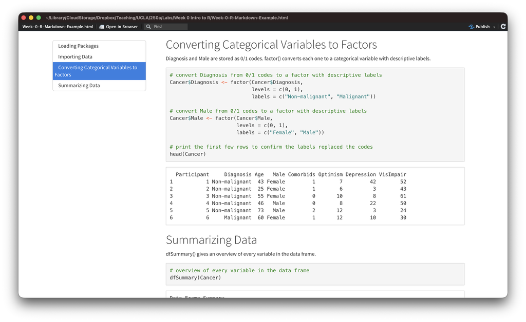

R runs the chunks from top to bottom in a fresh session, so the document must be self-contained: every package it uses is loaded in a chunk, and the data are read in a chunk, in the order they are needed. The output file is saved in the same folder as the `.Rmd` file, with the same name (spaces become dashes), and opens in a viewer when knitting finishes. If a chunk contains an error, knitting stops and the error message identifies the chunk. Fix the code and knit again.